# RM_project_auxillary_working_space

james c walmsley

12/16/2016

# Executive Summary:

[output not shown]

# Problem Statement & Questions to Answer:

```
            ## Q1 “Is an automatic or manual transmission better for 'mpg'”
            ## Q2 "Quantify the MPG difference between automatic and manual transmissions"
```

# Grading - Criteria (remove on completion)!!!

```
    ####YES!!!! Did the report include an executive summary?
    ####???? Did the student answer the questions of interest or detail why the question(s) is (are) not answerable?
    ####???? Did the student quantify the uncertainty in their conclusions and/or perform an inference correctly?
    ####???? Was the report brief (about 2 pages long) for the main body of the report and no longer than 5 with supporting appendix of figures?


    ####YES!!!! Did the student interpret the coefficients correctly?
    ####YES!!!! Did the student do some exploratory data analyses?


    ####YES!!!! Did the student fit multiple models and detail their strategy for model selection?
    ####Needs some more work


    ####YES!!!! Did the student do a residual plot and some diagnostics?
    ####YES!!!! Was the report done in Rmd (knitr) with pdf output?
```

# Analysis Considerations:

```
    Descriptive - (dim, mean, sd, sigma^2, str & summary) statistics

    Exploratory - pairs, histograms, QQ, fitted, residualplots, boxplots
    & (multiple plots); T-Test

    Analysis -  OLS, simple linear regression, statistical linear regression,
    multivariate regression & model selection, logistic regression, pValues,
    adjustments, residuals, residual fit, predict fit, hatvalues, variance, & dfbetas, R^2,
    diagnostics; ANOVA, coeficients, confint, correlation, covariance, variance inflation
```

# Software Environment: & System - session Info:

Set the Working Directory then get System & Session Info

# Accessing Data & Raw Data Overview: Motor Trend ‘mtcars’ data set:

Clean up the work space & import the data from the data sets package

A data frame with 32 observations on 11 variables.

[, 1] mpg Miles/(US) gallon  
[, 2] cyl Number of cylinders (4,6,8)  
[, 3] disp Displacement (cu.in.)  
[, 4] hp Gross horsepower  
[, 5] drat Rear axle ratio  
[, 6] wt Weight (1000 lbs)  
[, 7] qsec 1/4 mile time  
[, 8] vs V/S (V = vee-block, S = straight-block)  
[, 9] am Transmission (0 = automatic, 1 = manual)  
[,10] gear Number of forward gears (3,4,5)  
[,11] carb Number of carburetors (1,2,3,4,6,8)

# Process Data:

Factor columns 2 & 8:11 (cyl,vs,am,gear,carb) and order the data on mpg from the lowest to highest mpg rating

# Descriptive Statistics

# Exploratory Analysis:

Develop the r code for analyzing and identify any significant relationships / correlations between the range of mpg ratings and any of the other ten varialbes for observations contained in the data set. Use avaialbe regression model tools to find the best model fit, examine the coefficients, hatvalues, residuals, dfbetas, variance inflation, and R^2 values to spot over or underfitting of the model.

# Statistical Modeling:

[output not shown]

## Simple Linear Regression Plot

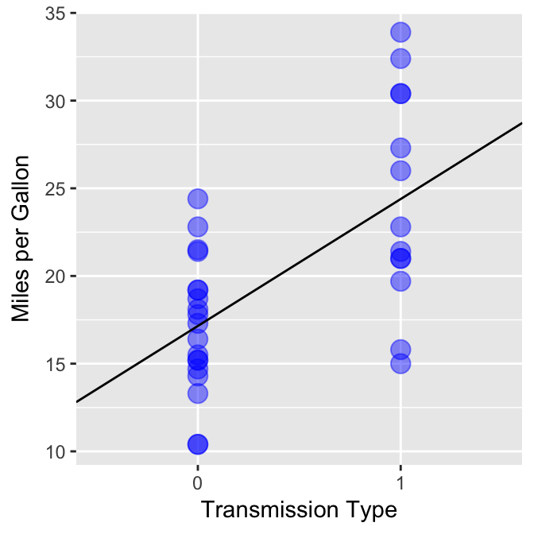

```r
## library(dplyr)
## ordmtcars$am <- factor(ordmtcars$am, labels = c("Auto", "Manual"))
## f1 <- lm(mpg ~ factor(am), data = ordmtcars)
## coef(summary(f1))
library(ggplot2)
par(mfrow = c(2,1), mar = c(4,4,2,2)) # set margin
g <- ggplot(ordmtcars, aes(x = factor(am), y = mpg),)
g <- g + xlab("Transmission Type")
g <- g + ylab("Miles per Gallon")
g <- g + geom_point(size = 4.0, col = "blue", alpha = .45)
g <- g + geom_abline(intercept = 9.91, slope = 7.24) # intercept adjusted (-7.24) to fit grid
g
```

## Bivariate Linear Model: # Note: manual trans & eng shape / vs are significant

First, using r command plot(f2) plot the four series plor for Reiduals vs Fitted, Normal QQ, Scale Location, and Residuals vs Leverage diagnostics plots of the bivariate model using; as.numeric(am) + wt.

Next, check coefficients summary (f2), hatvalues(f2),vif(f2), & sqrt(vif(f2)) for indications of poor model fit

Finally, fit a bivariate linear regression model using as.numeric(am) & wt.

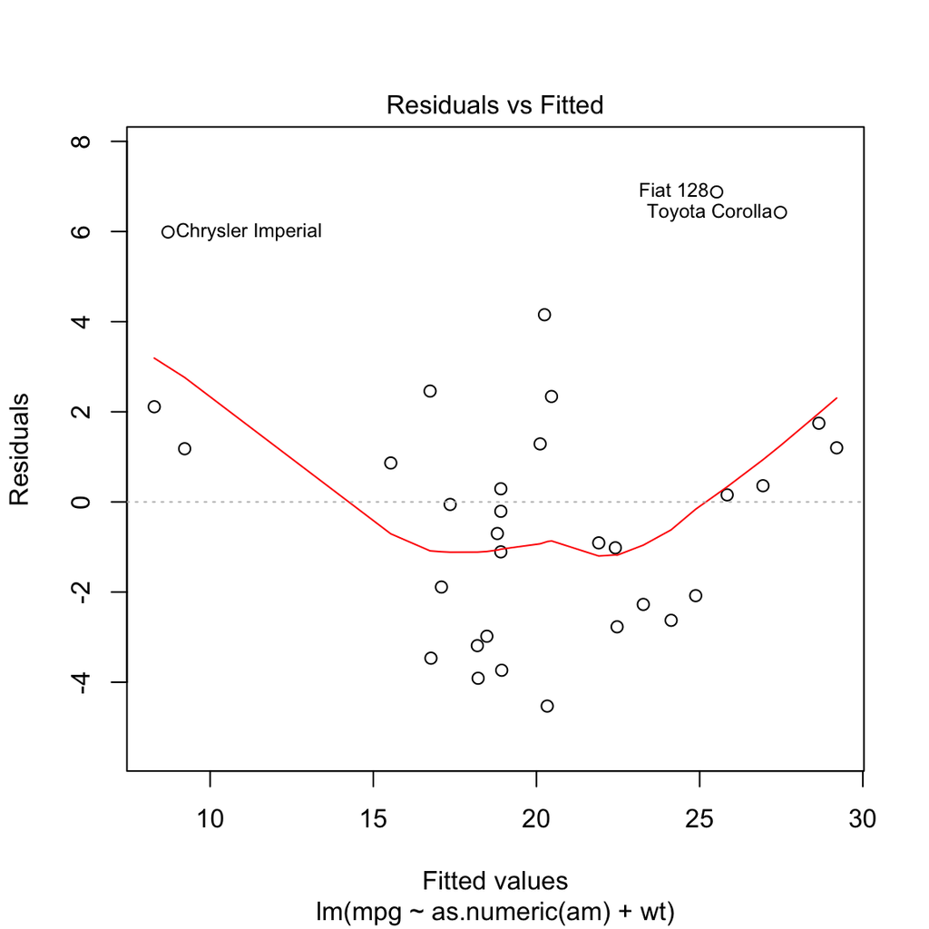

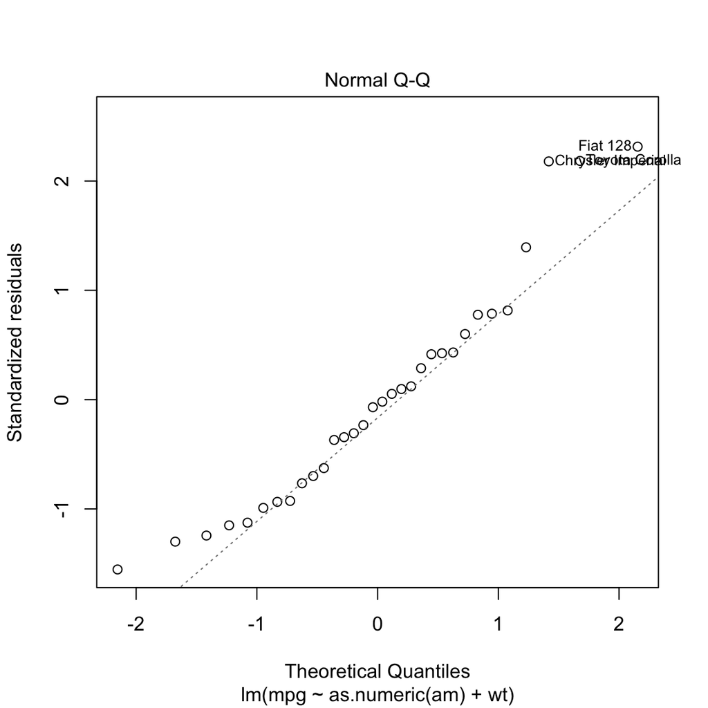

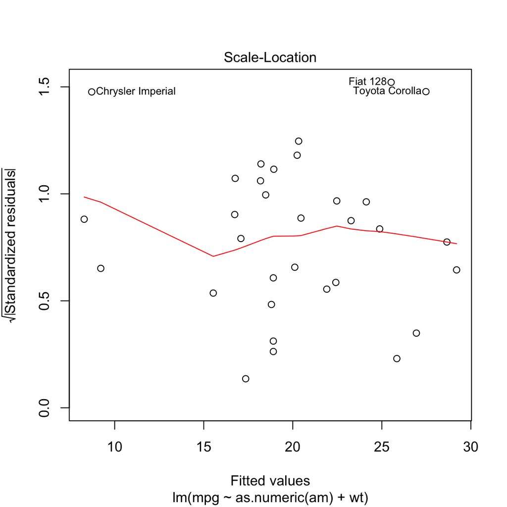

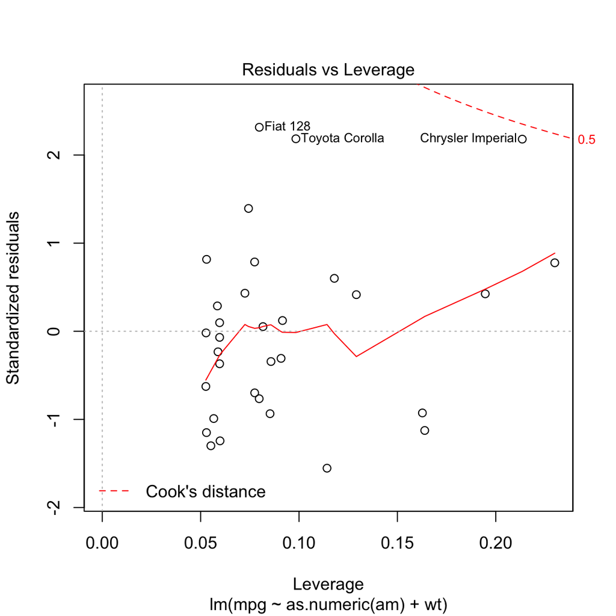

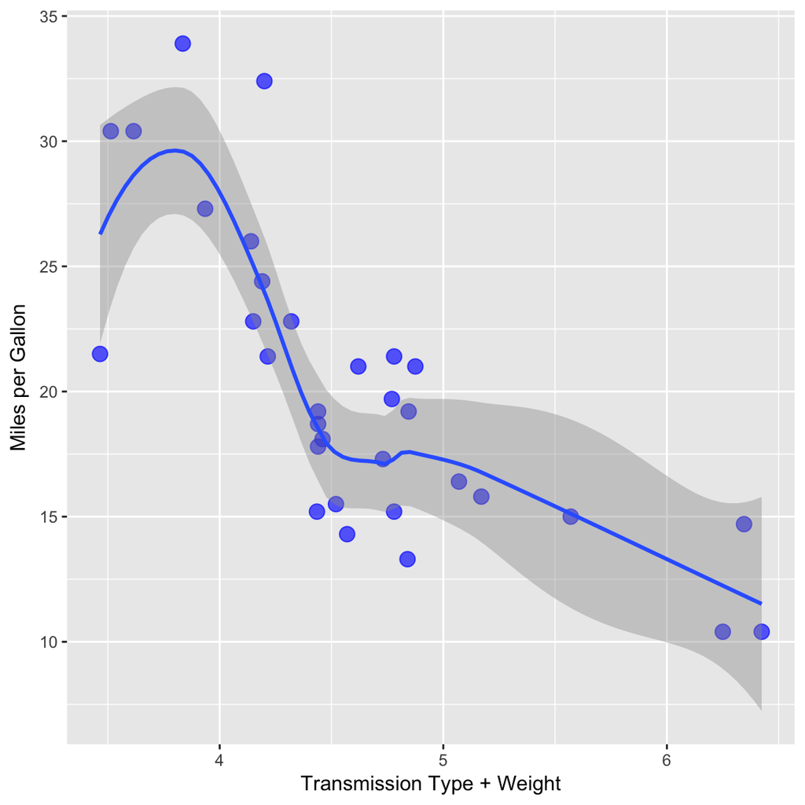